# Project - Predicting Potential Credit Card Payment Defaulters

# 2. Data Cleaning and Exploration

```python
credit_df.dtypes
```

```
Cust_ID           int64
Limit             int64
Gender            int64
Education         int64
Marriage          int64
Age               int64
SEP_PYMT_STS      int64
AUG_PYMT_STS      int64
JUL_PYMT_STS      int64
JUN_PYMT_STS      int64
MAY_PYMT_STS      int64
APR_PYMT_STS      int64
SEP_STMT        float64
AUG_STMT        float64
JUL_STMT        float64
JUN_STMT        float64
MAY_STMT        float64
APR_STMT        float64
SEP_PAID        float64
AUG_PAID        float64
JUL_PAID        float64
JUN_PAID        float64
MAY_PAID        float64
APR_PAID        float64
Default           int64
dtype: object
```

#### Plot missing values (if any)

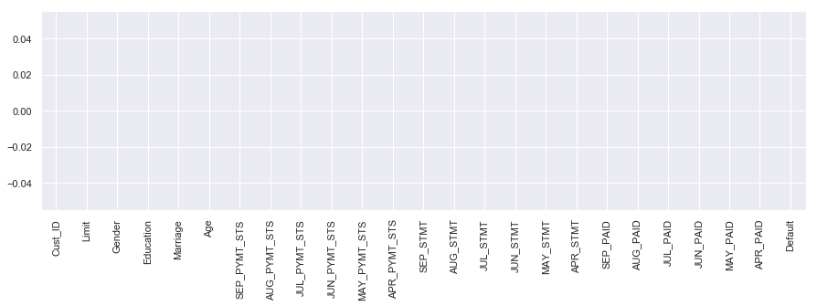

```python
col_null = credit_df.isnull().sum()
col_null_frac = col_null / credit_df.shape[0]

plt.figure(figsize= (15,4))
col_null_frac.plot(kind='bar')
```

There are no missing values. Hence any sort of imputation is not required

#### Check for duplicates based on the feature "cid"

```python
print(any(credit_df['Cust_ID'].duplicated()))
```

```
False
```

There are no duplicate Customers in the database

#### Check for zero values (if any)

```python
np.all(credit_df==0)
```

```
False
```

```python
print((credit_df.iloc[:] == 0).sum())
```

```
Cust_ID             0
Limit               0
Gender              0
Education          14
Marriage           54
Age                 0
SEP_PYMT_STS    14737
AUG_PYMT_STS    15730
JUL_PYMT_STS    15764
JUN_PYMT_STS    16455
MAY_PYMT_STS    16947
APR_PYMT_STS    16286
SEP_STMT         2008
AUG_STMT         2506
JUL_STMT         2870
JUN_STMT         3195
MAY_STMT         3506
APR_STMT         4020
SEP_PAID         5249
AUG_PAID         5396
JUL_PAID         5968
JUN_PAID         6408
MAY_PAID         6703
APR_PAID         7173
Default         23364
dtype: int64
```

Features such Education and Marriage has very less % of zero values. Can impute with the median value. The other features have no impact as 0 is valid value.

```python
credit_df_BK = credit_df
#credit_df = credit_df_BK
```

Not considering the features Cust_ID as will not be of any help in giving value add information.

```python
# Create a separate dataframe consisting only of the features i.e independent attributes

credit_feature_df = credit_df
```

Now it's time to look at the data and see what, if anything, looks weird or notable.

### Exploring categorical features representing in numeric (Label encoders)

```python
def doPlots(x, data, ii, fun):
    fig, axes = plt.subplots(len(ii) // 2, ncols = 2)
    fig.tight_layout()
    for i in range(len(ii)):
        fun(x=x[ii[i]], data=data, ax=axes[i // 2, i % 2], color='Blue')
    plt.show()
```

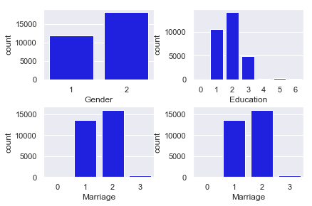

```python
import seaborn as sb
Label_encoders = ['Gender','Education','Marriage','Marriage']
doPlots(Label_encoders, credit_feature_df, range(0,4), sb.countplot)
```

Majority of Credit card Holers are females Majority of Credit card Holers are from University, Graduates followed by High school Majority of Credit card Holers are Single followed by Married

### Get Education qualification of Defaulters

```python
def calculate_percentage (default_count, total_count,label,label1):
    print "Percentage of {} {} {} ".format(label,label1,((total_count * 100) / default_count))
```

```python
Education_Category  = [1,2,3,4]
school_count        = credit_feature_df['Education'][credit_feature_df['Education']==1].count()
university_count    = credit_feature_df['Education'][credit_feature_df['Education']==2].count()
high_school_count   = credit_feature_df['Education'][credit_feature_df['Education']==3].count()
others_count        = credit_feature_df['Education'][credit_feature_df['Education']==4].count()

school_default      = credit_feature_df['Education'][(credit_feature_df['Education']==1)&(credit_feature_df['Default']==1)].count()
university_default  = credit_feature_df['Education'][(credit_feature_df['Education']==2)&(credit_feature_df['Default']==1)].count()
high_school_default = credit_feature_df['Education'][(credit_feature_df['Education']==3)&(credit_feature_df['Default']==1)].count()
others_default      = credit_feature_df['Education'][(credit_feature_df['Education']==4)&(credit_feature_df['Default']==1)].count()

education_total         = [school_count,university_count,high_school_count,others_count]
education_total_default = [school_default,university_default,high_school_default,others_default]
```

### Get Gender details of the Defaulters

```python
Gender_Category    = [1,2]
Male_count         = credit_feature_df['Gender'][credit_feature_df['Gender']==1].count()
Female_count       = credit_feature_df['Gender'][credit_feature_df['Gender']==2].count()

Male_default       = credit_feature_df['Gender'][(credit_feature_df['Gender']==1)&(credit_feature_df['Default']==1)].count()
Female_default     = credit_feature_df['Gender'][(credit_feature_df['Gender']==2)&(credit_feature_df['Default']==1)].count()

Gender_total         = [Male_count,Female_count]
gender_total_default = [Male_default,Female_default]
```

### Get Marriage details of Defaulters

```python
Marriage_Category   = [1,2,3]
married_count       = credit_feature_df['Marriage'][credit_feature_df['Marriage']==1].count()
single_count        = credit_feature_df['Marriage'][credit_feature_df['Marriage']==2].count()
others_count        = credit_feature_df['Marriage'][credit_feature_df['Marriage']==3].count()

married_default     = credit_feature_df['Marriage'][(credit_feature_df['Marriage']==1)&(credit_feature_df['Default']==1)].count()
single_default      = credit_feature_df['Marriage'][(credit_feature_df['Marriage']==2)&(credit_feature_df['Default']==1)].count()
others_default      = credit_feature_df['Marriage'][(credit_feature_df['Marriage']==3)&(credit_feature_df['Default']==1)].count()

marriage_total         = [married_count,single_count,others_count]
marriage_total_default = [married_default,single_default,others_default]
```

```
Percentage of High school Default is       25
Percentage of University Default is        23
Percentage of Graduate school Default is   19
Percentage of Others Default is            26
Percentage of Male Default is              24
Percentage of Female Default is            20
Percentage of Married Default is           23
Percentage of Single Default is            20
Percentage of Other Default is             26
Percentage of Married Male Default is      25
Percentage of Married Female Default is    21
Percentage of Single Male Default is       22
Percentage of Single Female Default is     19
```

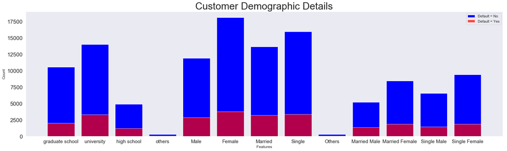

```python
Marriage_Category    = [1,2,3,4,5,6,7,8,9,10,11,12,13]
married_male_count   = credit_feature_df['Marriage'][(credit_feature_df['Marriage']==1)&(credit_feature_df['Gender']==1)].count()
married_female_count = credit_feature_df['Marriage'][(credit_feature_df['Marriage']==1)&(credit_feature_df['Gender']==2)].count()
single_male_count    = credit_feature_df['Marriage'][(credit_feature_df['Marriage']==2)&(credit_feature_df['Gender']==1)].count()
single_female_count  = credit_feature_df['Marriage'][(credit_feature_df['Marriage']==2)&(credit_feature_df['Gender']==2)].count()

married_male_default   = credit_feature_df['Marriage'][(credit_feature_df['Marriage']==1)&(credit_feature_df['Gender']==1)&(credit_feature_df['Default']==1)].count()
married_female_default = credit_feature_df['Marriage'][(credit_feature_df['Marriage']==1)&(credit_feature_df['Gender']==2)&(credit_feature_df['Default']==1)].count()
single_male_default    = credit_feature_df['Marriage'][(credit_feature_df['Marriage']==2)&(credit_feature_df['Gender']==1)&(credit_feature_df['Default']==1)].count()
single_female_default  = credit_feature_df['Marriage'][(credit_feature_df['Marriage']==2)&(credit_feature_df['Gender']==2)&(credit_feature_df['Default']==1)].count()


marriage_gender_total         = [school_count,university_count,high_school_count,others_count,Male_count,Female_count,married_count,single_count,others_count,married_male_count,married_female_count,single_male_count,single_female_count]
marriage_gender_total_default = [school_default,university_default,high_school_default,others_default,Male_default,Female_default,married_default,single_default,others_default,married_male_default,married_female_default,single_male_default,single_female_default]

#f, axes  = plt.subplots(1, figsize=(26,7))
plt.figure(figsize=(26,7))
plt.bar(Marriage_Category   , marriage_gender_total,label='Default = No',color='Blue')
plt.bar(Marriage_Category   , marriage_gender_total_default,label='Default = Yes',color='Red', alpha = 0.7)
plt.title("Customer Demographic Details",fontsize=30)
plt.xlabel("Features")
plt.ylabel("Count")
#plt.xlabel(fontsize=15)
plt.xticks(fontsize=15)
plt.yticks(fontsize=17)
plt.xticks(Marriage_Category,['graduate school','university','high school','others','Male','Female','Married','Single','Others','Married Male','Married Female','Single Male','Single Female'])
plt.legend()
plt.grid(False)

calculate_percentage(high_school_count,high_school_default,"High school Default is     ","")
calculate_percentage(university_count,university_default,  "University Default is      ","")
calculate_percentage(school_count,school_default,          "Graduate school Default is ","")
calculate_percentage(others_count,others_default,          "Others Default is          ","")
calculate_percentage(Male_count,Male_default,              "Male Default is            ","")
calculate_percentage(Female_count,Female_default,          "Female Default is          ","")
calculate_percentage(married_count,married_default,        "Married Default is         ","")
calculate_percentage(single_count,single_default,          "Single Default is          ","")
calculate_percentage(others_count,others_default,          "Other Default is           ","")
calculate_percentage(married_male_count,married_male_default, "Married Male Default is    ","")
calculate_percentage(married_female_count,married_female_default,"Married Female Default is  ","")
calculate_percentage(single_male_count,single_male_default,"Single Male Default is     ","")
calculate_percentage(single_female_count,single_female_default,"Single Female Default is   ","")
```

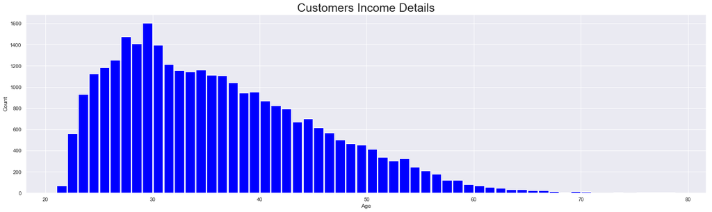

```python
# Distribution of Income wise representation

plt.figure(figsize=(26,7))
plt.hist(credit_feature_df['Age'], sorted(credit_feature_df['Age'].unique()),rwidth=0.9, color ='blue')
plt.title("Customers Income Details",fontsize=25)
plt.xlabel('Age')
plt.ylabel('Count')
plt.show()
```

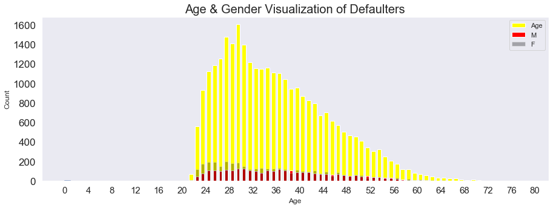

```python
x = np.linspace(0, 1, num=11)
y = np.linspace(1, .42, num=11)

f, axes  = plt.subplots(1, figsize=(15,5))
axes.plot(x,y)
locator=MaxNLocator(prune='both', nbins=25)
axes.xaxis.set_major_locator(locator)
#axes.yaxis.set_major_locator(locator)


axes.hist(credit_feature_df['Age'], sorted(credit_feature_df['Age'].unique()),rwidth=0.7, label='Age',color='yellow')
axes.hist(credit_feature_df[credit_feature_df.Gender == 1][credit_feature_df.Default == 1]['Age'], sorted(credit_feature_df['Age'].unique()),rwidth=0.5, label='M',color='red',alpha = 1.0)
axes.hist(credit_feature_df[credit_feature_df.Gender == 2][credit_feature_df.Default == 1]['Age'], sorted(credit_feature_df['Age'].unique()),rwidth=0.5, label='F',color='black',alpha = 0.3)
axes.set_xlabel('Age')
axes.set_ylabel('Count')
axes.set_title('Age & Gender Visualization of Defaulters',fontsize=20)
plt.xticks(fontsize=15)
plt.yticks(fontsize=17)
plt.grid(False)
axes.legend()
```

```python
for x in sorted(credit_feature_df['Age'].unique()):
    calculate_percentage(credit_feature_df['Age'][credit_feature_df['Age']==x ].count(),credit_feature_df['Age'][(credit_feature_df['Age']==x )&(credit_feature_df['Default']==1)].count(), x,"years default rate is")
```

```
Percentage of 21 years default rate is 20
Percentage of 22 years default rate is 30
Percentage of 23 years default rate is 26
Percentage of 24 years default rate is 26
Percentage of 25 years default rate is 25
Percentage of 26 years default rate is 20
Percentage of 27 years default rate is 21
Percentage of 28 years default rate is 20
Percentage of 29 years default rate is 19
Percentage of 30 years default rate is 19
Percentage of 31 years default rate is 18
Percentage of 32 years default rate is 19
Percentage of 33 years default rate is 18
Percentage of 34 years default rate is 19
Percentage of 35 years default rate is 20
Percentage of 36 years default rate is 22
Percentage of 37 years default rate is 21
Percentage of 38 years default rate is 20
Percentage of 39 years default rate is 20
Percentage of 40 years default rate is 21
Percentage of 41 years default rate is 22
Percentage of 42 years default rate is 23
Percentage of 43 years default rate is 22
Percentage of 44 years default rate is 23
Percentage of 45 years default rate is 18
Percentage of 46 years default rate is 27
Percentage of 47 years default rate is 23
Percentage of 48 years default rate is 22
Percentage of 49 years default rate is 26
Percentage of 50 years default rate is 24
Percentage of 51 years default rate is 25
Percentage of 52 years default rate is 25
Percentage of 53 years default rate is 22
Percentage of 54 years default rate is 22
Percentage of 55 years default rate is 27
Percentage of 56 years default rate is 27
Percentage of 57 years default rate is 22
Percentage of 58 years default rate is 25
Percentage of 59 years default rate is 25
Percentage of 60 years default rate is 34
Percentage of 61 years default rate is 37
Percentage of 62 years default rate is 15
Percentage of 63 years default rate is 25
Percentage of 64 years default rate is 29
Percentage of 65 years default rate is 20
Percentage of 66 years default rate is 28
Percentage of 67 years default rate is 31
Percentage of 68 years default rate is 20
Percentage of 69 years default rate is 20
Percentage of 70 years default rate is 20
Percentage of 71 years default rate is 0
Percentage of 72 years default rate is 33
Percentage of 73 years default rate is 75
Percentage of 74 years default rate is 0
Percentage of 75 years default rate is 33
Percentage of 79 years default rate is 0
```

```python
ageDF     = pd.DataFrame()
ageDF     = credit_feature_df['Age'].unique()
rec_count = ageDF.shape[0]
ageDF     = sorted(ageDF)
DfultDF   = pd.DataFrame()
arr       = []

for i in range(rec_count):
    arr.append(credit_feature_df['Age'][(credit_feature_df['Age']==ageDF[i] )&(credit_feature_df['Default']==1)].count())

DfultDF = arr
ageDF   = pd.DataFrame(ageDF)
DfultDF = pd.DataFrame(DfultDF)
ageDF.columns = ['Age']
DfultDF.columns = ['Default_Count']
ageDfult = pd.concat([ageDF,DfultDF], axis = 1)
```

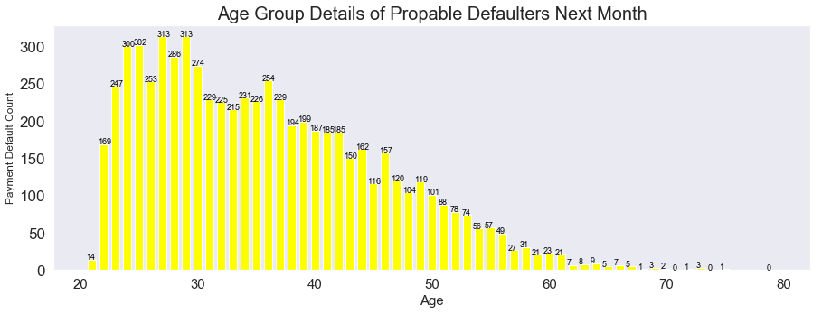

```python
plt.figure(figsize=(15,5))
barWidth = 0.7

plt.bar(ageDfult.Age, ageDfult.Default_Count,width = barWidth, color='yellow')
plt.title("Age Group Details of Propable Defaulters Next Month",fontsize=20)
plt.xlabel("Age",fontsize=15)
plt.ylabel("Payment Default Count")
plt.xticks(fontsize=15)
plt.yticks(fontsize=17)

# Text on the top of each barplot
for i in range(rec_count):
    plt.text(x = ageDfult.Age[i]-0.5 , y = ageDfult.Default_Count[i] +0.1,s = ageDfult.Default_Count[i], color = 'Black',size = 9)

plt.grid(False)
```

# 3. Descriptive statistics of numeric columns

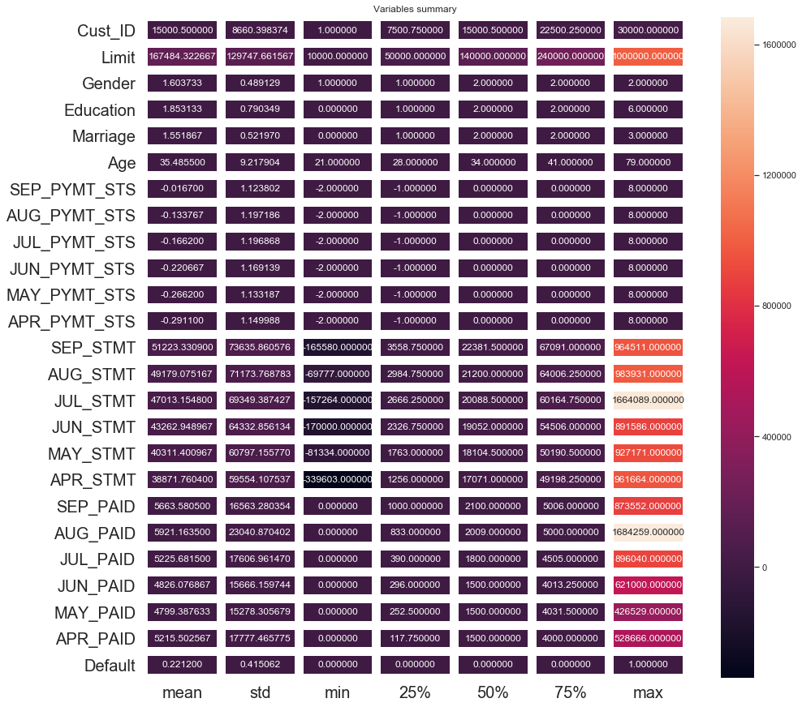

```python
plt.figure(figsize=(15,15))
sns.heatmap(credit_feature_df.describe()[1:].transpose(),linewidth=10,annot=True,fmt="f")
plt.xticks(fontsize=20)
plt.yticks(fontsize=20)
plt.title("Variables summary")
plt.show()
```

```python
credit_feature_df.describe().transpose() # Shows the Stats of only Numerical independent variables
```

|  | count | mean | std | min | 25% | 50% | 75% | max |
| --- | --- | --- | --- | --- | --- | --- | --- | --- |
| Cust_ID | 30000.0 | 15000.500000 | 8660.398374 | 1.0 | 7500.75 | 15000.5 | 22500.25 | 30000.0 |
| Limit | 30000.0 | 167484.322667 | 129747.661567 | 10000.0 | 50000.00 | 140000.0 | 240000.00 | 1000000.0 |
| Gender | 30000.0 | 1.603733 | 0.489129 | 1.0 | 1.00 | 2.0 | 2.00 | 2.0 |
| Education | 30000.0 | 1.853133 | 0.790349 | 0.0 | 1.00 | 2.0 | 2.00 | 6.0 |
| Marriage | 30000.0 | 1.551867 | 0.521970 | 0.0 | 1.00 | 2.0 | 2.00 | 3.0 |
| Age | 30000.0 | 35.485500 | 9.217904 | 21.0 | 28.00 | 34.0 | 41.00 | 79.0 |
| SEP_PYMT_STS | 30000.0 | -0.016700 | 1.123802 | -2.0 | -1.00 | 0.0 | 0.00 | 8.0 |
| AUG_PYMT_STS | 30000.0 | -0.133767 | 1.197186 | -2.0 | -1.00 | 0.0 | 0.00 | 8.0 |
| JUL_PYMT_STS | 30000.0 | -0.166200 | 1.196868 | -2.0 | -1.00 | 0.0 | 0.00 | 8.0 |
| JUN_PYMT_STS | 30000.0 | -0.220667 | 1.169139 | -2.0 | -1.00 | 0.0 | 0.00 | 8.0 |
| MAY_PYMT_STS | 30000.0 | -0.266200 | 1.133187 | -2.0 | -1.00 | 0.0 | 0.00 | 8.0 |
| APR_PYMT_STS | 30000.0 | -0.291100 | 1.149988 | -2.0 | -1.00 | 0.0 | 0.00 | 8.0 |
| SEP_STMT | 30000.0 | 51223.330900 | 73635.860576 | -165580.0 | 3558.75 | 22381.5 | 67091.00 | 964511.0 |
| AUG_STMT | 30000.0 | 49179.075167 | 71173.768783 | -69777.0 | 2984.75 | 21200.0 | 64006.25 | 983931.0 |
| JUL_STMT | 30000.0 | 47013.154800 | 69349.387427 | -157264.0 | 2666.25 | 20088.5 | 60164.75 | 1664089.0 |
| JUN_STMT | 30000.0 | 43262.948967 | 64332.856134 | -170000.0 | 2326.75 | 19052.0 | 54506.00 | 891586.0 |
| MAY_STMT | 30000.0 | 40311.400967 | 60797.155770 | -81334.0 | 1763.00 | 18104.5 | 50190.50 | 927171.0 |
| APR_STMT | 30000.0 | 38871.760400 | 59554.107537 | -339603.0 | 1256.00 | 17071.0 | 49198.25 | 961664.0 |
| SEP_PAID | 30000.0 | 5663.580500 | 16563.280354 | 0.0 | 1000.00 | 2100.0 | 5006.00 | 873552.0 |
| AUG_PAID | 30000.0 | 5921.163500 | 23040.870402 | 0.0 | 833.00 | 2009.0 | 5000.00 | 1684259.0 |
| JUL_PAID | 30000.0 | 5225.681500 | 17606.961470 | 0.0 | 390.00 | 1800.0 | 4505.00 | 896040.0 |
| JUN_PAID | 30000.0 | 4826.076867 | 15666.159744 | 0.0 | 296.00 | 1500.0 | 4013.25 | 621000.0 |
| MAY_PAID | 30000.0 | 4799.387633 | 15278.305679 | 0.0 | 252.50 | 1500.0 | 4031.50 | 426529.0 |
| APR_PAID | 30000.0 | 5215.502567 | 17777.465775 | 0.0 | 117.75 | 1500.0 | 4000.00 | 528666.0 |
| Default | 30000.0 | 0.221200 | 0.415062 | 0.0 | 0.00 | 0.0 | 0.00 | 1.0 |

### Plot to get correlated variables

```python
corr = credit_feature_df.corr()
corr
```

|  | Cust_ID | Limit | Gender | Education | Marriage | Age | SEP_PYMT_STS | AUG_PYMT_STS | JUL_PYMT_STS | JUN_PYMT_STS | ... | JUN_STMT | MAY_STMT | APR_STMT | SEP_PAID | AUG_PAID | JUL_PAID | JUN_PAID | MAY_PAID | APR_PAID | Default |
| --- | --- | --- | --- | --- | --- | --- | --- | --- | --- | --- | --- | --- | --- | --- | --- | --- | --- | --- | --- | --- | --- |
| Cust_ID | 1.000000 | 0.026179 | 0.018497 | 0.039177 | -0.029079 | 0.018678 | -0.030575 | -0.011215 | -0.018494 | -0.002735 | ... | 0.040351 | 0.016705 | 0.016730 | 0.009742 | 0.008406 | 0.039151 | 0.007793 | 0.000652 | 0.003000 | -0.013952 |
| Limit | 0.026179 | 1.000000 | 0.024755 | -0.219161 | -0.108139 | 0.144713 | -0.271214 | -0.296382 | -0.286123 | -0.267460 | ... | 0.293988 | 0.295562 | 0.290389 | 0.195236 | 0.178408 | 0.210167 | 0.203242 | 0.217202 | 0.219595 | -0.153520 |
| Gender | 0.018497 | 0.024755 | 1.000000 | 0.014232 | -0.031389 | -0.090874 | -0.057643 | -0.070771 | -0.066096 | -0.060173 | ... | -0.021880 | -0.017005 | -0.016733 | -0.000242 | -0.001391 | -0.008597 | -0.002229 | -0.001667 | -0.002766 | -0.039961 |
| Education | 0.039177 | -0.219161 | 0.014232 | 1.000000 | -0.143464 | 0.175061 | 0.105364 | 0.121566 | 0.114025 | 0.108793 | ... | -0.000451 | -0.007567 | -0.009099 | -0.037456 | -0.030038 | -0.039943 | -0.038218 | -0.040358 | -0.037200 | 0.028006 |
| Marriage | -0.029079 | -0.108139 | -0.031389 | -0.143464 | 1.000000 | -0.414170 | 0.019917 | 0.024199 | 0.032688 | 0.033122 | ... | -0.023344 | -0.025393 | -0.021207 | -0.005979 | -0.008093 | -0.003541 | -0.012659 | -0.001205 | -0.006641 | -0.024339 |
| Age | 0.018678 | 0.144713 | -0.090874 | 0.175061 | -0.414170 | 1.000000 | -0.039447 | -0.050148 | -0.053048 | -0.049722 | ... | 0.051353 | 0.049345 | 0.047613 | 0.026147 | 0.021785 | 0.029247 | 0.021379 | 0.022850 | 0.019478 | 0.013890 |
| SEP_PYMT_STS | -0.030575 | -0.271214 | -0.057643 | 0.105364 | 0.019917 | -0.039447 | 1.000000 | 0.672164 | 0.574245 | 0.538841 | ... | 0.179125 | 0.180635 | 0.176980 | -0.079269 | -0.070101 | -0.070561 | -0.064005 | -0.058190 | -0.058673 | 0.324794 |
| AUG_PYMT_STS | -0.011215 | -0.296382 | -0.070771 | 0.121566 | 0.024199 | -0.050148 | 0.672164 | 1.000000 | 0.766552 | 0.662067 | ... | 0.222237 | 0.221348 | 0.219403 | -0.080701 | -0.058990 | -0.055901 | -0.046858 | -0.037093 | -0.036500 | 0.263551 |
| JUL_PYMT_STS | -0.018494 | -0.286123 | -0.066096 | 0.114025 | 0.032688 | -0.053048 | 0.574245 | 0.766552 | 1.000000 | 0.777359 | ... | 0.227202 | 0.225145 | 0.222327 | 0.001295 | -0.066793 | -0.053311 | -0.046067 | -0.035863 | -0.035861 | 0.235253 |
| JUN_PYMT_STS | -0.002735 | -0.267460 | -0.060173 | 0.108793 | 0.033122 | -0.049722 | 0.538841 | 0.662067 | 0.777359 | 1.000000 | ... | 0.245917 | 0.242902 | 0.239154 | -0.009362 | -0.001944 | -0.069235 | -0.043461 | -0.033590 | -0.026565 | 0.216614 |
| MAY_PYMT_STS | -0.022199 | -0.249411 | -0.055064 | 0.097520 | 0.035629 | -0.053826 | 0.509426 | 0.622780 | 0.686775 | 0.819835 | ... | 0.271915 | 0.269783 | 0.262509 | -0.006089 | -0.003191 | 0.009062 | -0.058299 | -0.033337 | -0.023027 | 0.204149 |
| APR_PYMT_STS | -0.020270 | -0.235195 | -0.044008 | 0.082316 | 0.034345 | -0.048773 | 0.474553 | 0.575501 | 0.632684 | 0.716449 | ... | 0.266356 | 0.290894 | 0.285091 | -0.001496 | -0.005223 | 0.005834 | 0.019018 | -0.046434 | -0.025299 | 0.186866 |
| SEP_STMT | 0.019389 | 0.285430 | -0.033642 | 0.023581 | -0.023472 | 0.056239 | 0.187068 | 0.234887 | 0.208473 | 0.202812 | ... | 0.860272 | 0.829779 | 0.802650 | 0.140277 | 0.099355 | 0.156887 | 0.158303 | 0.167026 | 0.179341 | -0.019644 |
| AUG_STMT | 0.017982 | 0.278314 | -0.031183 | 0.018749 | -0.021602 | 0.054283 | 0.189859 | 0.235257 | 0.237295 | 0.225816 | ... | 0.892482 | 0.859778 | 0.831594 | 0.280365 | 0.100851 | 0.150718 | 0.147398 | 0.157957 | 0.174256 | -0.014193 |
| JUL_STMT | 0.024354 | 0.283236 | -0.024563 | 0.013002 | -0.024909 | 0.053710 | 0.179785 | 0.224146 | 0.227494 | 0.244983 | ... | 0.923969 | 0.883910 | 0.853320 | 0.244335 | 0.316936 | 0.130011 | 0.143405 | 0.179712 | 0.182326 | -0.014076 |
| JUN_STMT | 0.040351 | 0.293988 | -0.021880 | -0.000451 | -0.023344 | 0.051353 | 0.179125 | 0.222237 | 0.227202 | 0.245917 | ... | 1.000000 | 0.940134 | 0.900941 | 0.233012 | 0.207564 | 0.300023 | 0.130191 | 0.160433 | 0.177637 | -0.010156 |
| MAY_STMT | 0.016705 | 0.295562 | -0.017005 | -0.007567 | -0.025393 | 0.049345 | 0.180635 | 0.221348 | 0.225145 | 0.242902 | ... | 0.940134 | 1.000000 | 0.946197 | 0.217031 | 0.181246 | 0.252305 | 0.293118 | 0.141574 | 0.164184 | -0.006760 |
| APR_STMT | 0.016730 | 0.290389 | -0.016733 | -0.009099 | -0.021207 | 0.047613 | 0.176980 | 0.219403 | 0.222327 | 0.239154 | ... | 0.900941 | 0.946197 | 1.000000 | 0.199965 | 0.172663 | 0.233770 | 0.250237 | 0.307729 | 0.115494 | -0.005372 |
| SEP_PAID | 0.009742 | 0.195236 | -0.000242 | -0.037456 | -0.005979 | 0.026147 | -0.079269 | -0.080701 | 0.001295 | -0.009362 | ... | 0.233012 | 0.217031 | 0.199965 | 1.000000 | 0.285576 | 0.252191 | 0.199558 | 0.148459 | 0.185735 | -0.072929 |
| AUG_PAID | 0.008406 | 0.178408 | -0.001391 | -0.030038 | -0.008093 | 0.021785 | -0.070101 | -0.058990 | -0.066793 | -0.001944 | ... | 0.207564 | 0.181246 | 0.172663 | 0.285576 | 1.000000 | 0.244770 | 0.180107 | 0.180908 | 0.157634 | -0.058579 |
| JUL_PAID | 0.039151 | 0.210167 | -0.008597 | -0.039943 | -0.003541 | 0.029247 | -0.070561 | -0.055901 | -0.053311 | -0.069235 | ... | 0.300023 | 0.252305 | 0.233770 | 0.252191 | 0.244770 | 1.000000 | 0.216325 | 0.159214 | 0.162740 | -0.056250 |
| JUN_PAID | 0.007793 | 0.203242 | -0.002229 | -0.038218 | -0.012659 | 0.021379 | -0.064005 | -0.046858 | -0.046067 | -0.043461 | ... | 0.130191 | 0.293118 | 0.250237 | 0.199558 | 0.180107 | 0.216325 | 1.000000 | 0.151830 | 0.157834 | -0.056827 |
| MAY_PAID | 0.000652 | 0.217202 | -0.001667 | -0.040358 | -0.001205 | 0.022850 | -0.058190 | -0.037093 | -0.035863 | -0.033590 | ... | 0.160433 | 0.141574 | 0.307729 | 0.148459 | 0.180908 | 0.159214 | 0.151830 | 1.000000 | 0.154896 | -0.055124 |
| APR_PAID | 0.003000 | 0.219595 | -0.002766 | -0.037200 | -0.006641 | 0.019478 | -0.058673 | -0.036500 | -0.035861 | -0.026565 | ... | 0.177637 | 0.164184 | 0.115494 | 0.185735 | 0.157634 | 0.162740 | 0.157834 | 0.154896 | 1.000000 | -0.053183 |
| Default | -0.013952 | -0.153520 | -0.039961 | 0.028006 | -0.024339 | 0.013890 | 0.324794 | 0.263551 | 0.235253 | 0.216614 | ... | -0.010156 | -0.006760 | -0.005372 | -0.072929 | -0.058579 | -0.056250 | -0.056827 | -0.055124 | -0.053183 | 1.000000 |

25 rows × 25 columns

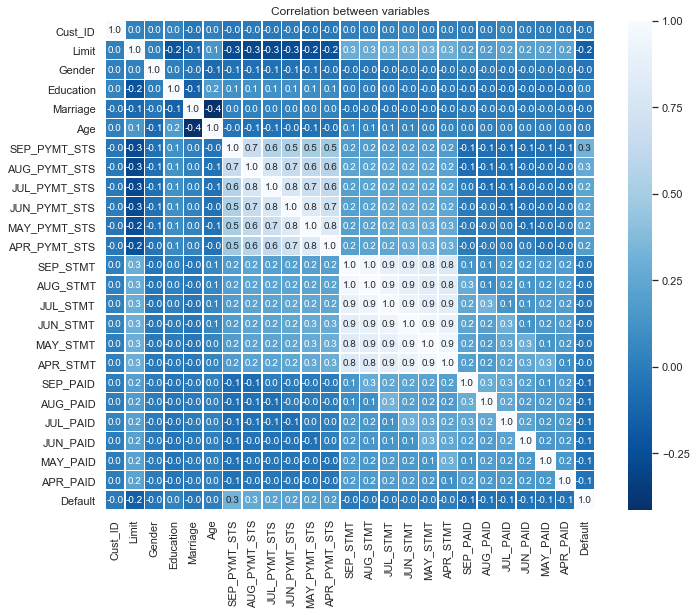

```python
mask = np.zeros_like(corr)
mask[np.triu_indices_from(mask)] = True

plt.figure(figsize=(12,9))

with sns.axes_style("white"):
    sns.heatmap(corr,annot=True,fmt=".1f",linewidth=0.5, square = True,cmap="Blues_r",annot_kws={"size":10})
plt.title("Correlation between variables")
plt.show()
```

### Create new column to capture missing payment count (if any) in last 6 months for each customer

```python
# payment_miss_in_6_months = 0, customer not defaulted payment
# no_payment_last_4_months > 0, meaning customer defaulted n times in last six months

df = pd.DataFrame(credit_feature_df[['SEP_PAID','AUG_PAID','JUL_PAID','JUN_PAID','MAY_PAID','APR_PAID']])
Count = pd.DataFrame()
Count = df.apply( lambda s : s.value_counts().get(0,0), axis=1)
credit_feature_df['payment_miss_in_6_months']   = Count
del(df)
del(Count)
```

```python
credit_feature_df.shape # New column added
```

```
(30000, 26)
```

Contains 30000 rows with 26 columns

```python
credit_feature_df.head(1)
```

|  | Cust_ID | Limit | Gender | Education | Marriage | Age | SEP_PYMT_STS | AUG_PYMT_STS | JUL_PYMT_STS | JUN_PYMT_STS | ... | MAY_STMT | APR_STMT | SEP_PAID | AUG_PAID | JUL_PAID | JUN_PAID | MAY_PAID | APR_PAID | Default | payment_miss_in_6_months |
| --- | --- | --- | --- | --- | --- | --- | --- | --- | --- | --- | --- | --- | --- | --- | --- | --- | --- | --- | --- | --- | --- |
| 0 | 1 | 20000 | 2 | 2 | 1 | 24 | 2 | 2 | -1 | -1 | ... | 0.0 | 0.0 | 0.0 | 689.0 | 0.0 | 0.0 | 0.0 | 0.0 | 1 | 5 |

1 rows × 26 columns

[figure not shown]

```python
Marriage_Category    = [1,2,3,4,5,6,7,8,9,10,11,12,13]


married_male_default   = credit_feature_df['Marriage'][(credit_feature_df['Marriage']==1)&(credit_feature_df['Gender']==1)&(credit_feature_df['payment_miss_in_6_months']>4)].count()
married_female_default = credit_feature_df['Marriage'][(credit_feature_df['Marriage']==1)&(credit_feature_df['Gender']==2)&(credit_feature_df['payment_miss_in_6_months']>4)].count()
single_male_default    = credit_feature_df['Marriage'][(credit_feature_df['Marriage']==2)&(credit_feature_df['Gender']==1)&(credit_feature_df['payment_miss_in_6_months']>4)].count()
single_female_default  = credit_feature_df['Marriage'][(credit_feature_df['Marriage']==2)&(credit_feature_df['Gender']==2)&(credit_feature_df['payment_miss_in_6_months']>4)].count()


marriage_gender_total_default = [school_default,university_default,high_school_default,others_default,Male_default,Female_default,married_default,single_default,others_default,married_male_default,married_female_default,single_male_default,single_female_default]

plt.figure(figsize=(26,7))
barWidth = 0.7
plt.bar(Marriage_Category, marriage_gender_total_default, width = barWidth,color='Red', alpha = 0.7)
plt.title("Customer Demographic Details Who Defaulted Atleast 4 times In Last 6 Months",fontsize=25)
plt.xlabel("Features",fontsize=30)
plt.ylabel("Default Count",fontsize=30)
plt.xticks(fontsize=15)
plt.yticks(fontsize=17)
plt.xticks(Marriage_Category,['graduate school','university','high school','others','Male','Female','Married','Single','Others','Married Male','Married Female','Single Male','Single Female'])
#plt.legend()


for i in range(13):
    plt.text(x = Marriage_Category[i]-0.2 , y = marriage_gender_total_default[i] +0.2,s = marriage_gender_total_default[i], color = 'Black',size = 19)



plt.grid(False)
```

### Create new column to capture last four months continious defaulters data

```python
# no_payment_last_4_months = 0, customer not defaulted continiously for four months
# no_payment_last_4_months = 1, meaning customer defaulted continiously for four months

df = pd.DataFrame(credit_feature_df[['SEP_PAID','AUG_PAID','JUL_PAID','JUN_PAID']])
Count = pd.DataFrame()
Count = df.apply( lambda s : s.value_counts().get(0,0), axis=1)
credit_feature_df['no_payment_last_4_months']   = Count
del(df)
del(Count)
```

```python
credit_feature_df.loc[credit_feature_df['no_payment_last_4_months'] < 4, 'no_payment_last_4_months'] = 0
credit_feature_df.loc[credit_feature_df['no_payment_last_4_months'] == 4, 'no_payment_last_4_months'] = 1
```

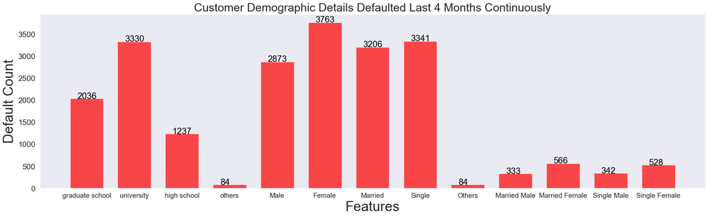

```python
Marriage_Category    = [1,2,3,4,5,6,7,8,9,10,11,12,13]


married_male_default   = credit_feature_df['Marriage'][(credit_feature_df['Marriage']==1)&(credit_feature_df['Gender']==1)&(credit_feature_df['no_payment_last_4_months']==1)].count()
married_female_default = credit_feature_df['Marriage'][(credit_feature_df['Marriage']==1)&(credit_feature_df['Gender']==2)&(credit_feature_df['no_payment_last_4_months']==1)].count()
single_male_default    = credit_feature_df['Marriage'][(credit_feature_df['Marriage']==2)&(credit_feature_df['Gender']==1)&(credit_feature_df['no_payment_last_4_months']==1)].count()
single_female_default  = credit_feature_df['Marriage'][(credit_feature_df['Marriage']==2)&(credit_feature_df['Gender']==2)&(credit_feature_df['no_payment_last_4_months']==1)].count()


marriage_gender_total_default = [school_default,university_default,high_school_default,others_default,Male_default,Female_default,married_default,single_default,others_default,married_male_default,married_female_default,single_male_default,single_female_default]

plt.figure(figsize=(26,7))
barWidth = 0.7
plt.bar(Marriage_Category, marriage_gender_total_default, width = barWidth,color='Red', alpha = 0.7)
plt.title("Customer Demographic Details Defaulted Last 4 Months Continuously",fontsize=25)
plt.xlabel("Features",fontsize=30)
plt.ylabel("Default Count",fontsize=30)
plt.xticks(fontsize=15)
plt.yticks(fontsize=17)
plt.xticks(Marriage_Category,['graduate school','university','high school','others','Male','Female','Married','Single','Others','Married Male','Married Female','Single Male','Single Female'])
#plt.legend()


for i in range(13):
    plt.text(x = Marriage_Category[i]-0.2 , y = marriage_gender_total_default[i] +0.2,s = marriage_gender_total_default[i], color = 'Black',size = 19)
plt.grid(False)
```

# End of EDA Phase

```python
credit_feature_df = credit_feature_df.drop(['Cust_ID'], axis=1)
```

```python
# change the sequence of the columns
credit_feature_df = credit_feature_df[['Limit','Gender','Education','Marriage','Age','SEP_PYMT_STS','AUG_PYMT_STS',
                                       'JUL_PYMT_STS','JUN_PYMT_STS','MAY_PYMT_STS','APR_PYMT_STS', 'SEP_STMT','AUG_STMT',
                                       'JUL_STMT','JUN_STMT','MAY_STMT','APR_STMT','SEP_PAID','AUG_PAID','JUL_PAID',
                                       'JUN_PAID','MAY_PAID','APR_PAID','payment_miss_in_6_months','no_payment_last_4_months',
                                       'Default']]
```

```python
credit_df_BK = credit_feature_df
```

## Apply multiple classification models to extract the Important features

```python
Model     = []
Accuracy  = []
AUC       = []

def show_features(db,coeff,Score,roc,heading):

    Score        = Score *100
    Coefficients = pd.DataFrame(coeff)

    if (heading == "Logistic Regression"):
        Coefficients         = np.transpose(Coefficients)

    Coefficients.columns = ['Coefficients']
    Features = pd.DataFrame(list(db.iloc[:,:-1]))
    Features.columns = ['Features']
    Features = pd.concat([Features,Coefficients,],axis=1)
    print(Features)
    print(" ")
    print("Accuracy : %.2f" % Score)
    print('AUC      : %.2f' % roc)


    f, ax = plt.subplots(figsize=(10, 5))
    sns.barplot(x=Features["Features"],y= Features["Coefficients"],palette="prism",linewidth=1,edgecolor="Black",ax=ax)
    sns.set_context('talk')
    ax.tick_params(axis='x', colors='black')
    ax.tick_params(axis='y', colors='blue')
    header = "Feature Importance by " + heading
    plt.title(header,fontsize = 14,weight = 'bold')
    plt.xlabel('Features', fontsize = 15, weight = 'bold')
    plt.xticks(rotation=90)
    plt.ylabel('Coefficients', fontsize = 15, weight = 'bold')
    plt.grid(False)
    plt.show()

    Model.append(heading)
    Accuracy.append(Score)
    AUC.append(roc)

    return
```

```python
Model_     = []
Accuracy_  = []
AUC_       = []

def Get_Metrics(Score,roc,heading):

    Score  = Score *100
    Model_.append(heading)
    Accuracy_.append(Score)
    AUC_.append(roc)

    print(heading)
    print("Accuracy : %.2f" % Score)
    print('AUC      : %.2f' % roc)
    return
```

## Split the data into training and test set in the ratio of 70:30 (Training:Test)

```python
data,label =credit_feature_df.iloc[:,:-1],credit_feature_df.iloc[:,-1]
train_data, test_data, train_label, test_label = train_test_split(data, label, test_size=0.3, random_state=123)
```

### Logistic Regression

```
                    Features  Coefficients
0                      Limit -2.725531e-06
1                     Gender -1.407047e-03
2                  Education -1.535261e-03
3                   Marriage -1.490192e-03
4                        Age -1.771665e-02
5               SEP_PYMT_STS  3.010600e-03
6               AUG_PYMT_STS  2.380029e-03
7               JUL_PYMT_STS  2.143079e-03
8               JUN_PYMT_STS  1.934696e-03
9               MAY_PYMT_STS  1.825444e-03
10              APR_PYMT_STS  1.737464e-03
11                  SEP_STMT -8.609786e-06
12                  AUG_STMT  5.247584e-06
13                  JUL_STMT  1.356429e-06
14                  JUN_STMT  8.358867e-07
15                  MAY_STMT  3.852963e-06
16                  APR_STMT  2.032646e-06
17                  SEP_PAID -2.775226e-05
18                  AUG_PAID -1.799230e-05
19                  JUL_PAID -1.268906e-05
20                  JUN_PAID -1.224369e-05
21                  MAY_PAID -3.576705e-06
22                  APR_PAID -3.068612e-06
23  payment_miss_in_6_months  1.742225e-03
24  no_payment_last_4_months  1.984662e-04

Accuracy : 78.34
AUC      : 0.65
```

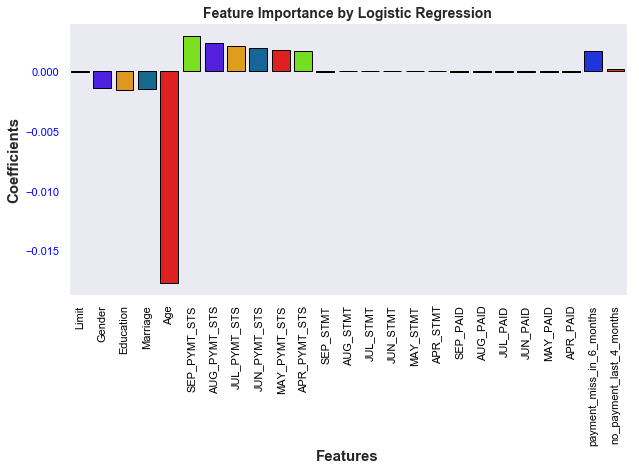

```python
from sklearn.linear_model import LogisticRegression

heading = "Logistic Regression"
lr      = LogisticRegression()
lr.fit(train_data,train_label)

Pred       = lr.predict(test_data)
Pred_proba = lr.predict_proba(test_data)[:, 1]
score      = lr.score(test_data,test_label)
roc_score  = roc_auc_score(test_label, Pred_proba)

show_features(credit_feature_df,lr.coef_,score,roc_score,heading)
del(Pred)
del(Pred_proba)
del(score)
del(roc_score)
```

### Decision Tree Classifier

```
                    Features  Coefficients
0                      Limit      0.057176
1                     Gender      0.009670
2                  Education      0.022549
3                   Marriage      0.013598
4                        Age      0.075049
5               SEP_PYMT_STS      0.162277
6               AUG_PYMT_STS      0.038020
7               JUL_PYMT_STS      0.011398
8               JUN_PYMT_STS      0.006634
9               MAY_PYMT_STS      0.010018
10              APR_PYMT_STS      0.010692
11                  SEP_STMT      0.059070
12                  AUG_STMT      0.055110
13                  JUL_STMT      0.048022
14                  JUN_STMT      0.045684
15                  MAY_STMT      0.037405
16                  APR_STMT      0.044254
17                  SEP_PAID      0.043419
18                  AUG_PAID      0.046101
19                  JUL_PAID      0.058360
20                  JUN_PAID      0.044767
21                  MAY_PAID      0.043474
22                  APR_PAID      0.045419
23  payment_miss_in_6_months      0.010351
24  no_payment_last_4_months      0.001482

Accuracy : 72.54
AUC      : 0.62
```

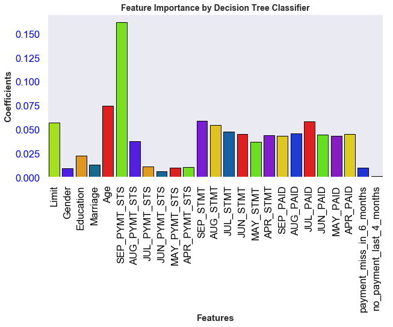

```python
from sklearn.tree import DecisionTreeClassifier

heading = "Decision Tree Classifier"

dtc = DecisionTreeClassifier()
dtc.fit(train_data,train_label)
Pred       = dtc.predict(test_data)
Pred_proba = dtc.predict_proba(test_data)[:, 1]
score      = dtc.score(test_data,test_label)
roc_score  = roc_auc_score(test_label, Pred_proba)
show_features(credit_feature_df,dtc.feature_importances_,score,roc_score,heading)

del(Pred)
del(Pred_proba)
del(score)
del(roc_score)
```

### Random Forest Classifier

```
                    Features  Coefficients
0                      Limit      0.057903
1                     Gender      0.012561
2                  Education      0.020686
3                   Marriage      0.013834
4                        Age      0.066894
5               SEP_PYMT_STS      0.090317
6               AUG_PYMT_STS      0.059089
7               JUL_PYMT_STS      0.017142
8               JUN_PYMT_STS      0.024862
9               MAY_PYMT_STS      0.019782
10              APR_PYMT_STS      0.013862
11                  SEP_STMT      0.058784
12                  AUG_STMT      0.052453
13                  JUL_STMT      0.048830
14                  JUN_STMT      0.045849
15                  MAY_STMT      0.046153
16                  APR_STMT      0.050494
17                  SEP_PAID      0.049272
18                  AUG_PAID      0.047714
19                  JUL_PAID      0.046472
20                  JUN_PAID      0.042633
21                  MAY_PAID      0.044280
22                  APR_PAID      0.044528
23  payment_miss_in_6_months      0.023320
24  no_payment_last_4_months      0.002287

Accuracy : 80.49
AUC      : 0.72
```

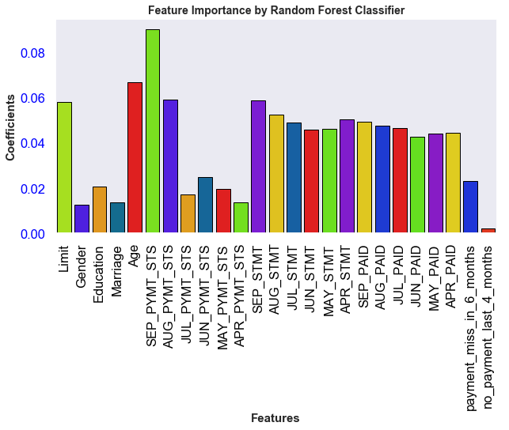

```python
from sklearn.ensemble import RandomForestClassifier

heading = "Random Forest Classifier"

rc = RandomForestClassifier()
rc.fit(train_data,train_label)
Pred       = rc.predict(test_data)
Pred_proba = rc.predict_proba(test_data)[:, 1]
score = rc.score(test_data,test_label)
roc_score  = roc_auc_score(test_label, Pred_proba)

show_features(credit_feature_df,rc.feature_importances_,score,roc_score,heading)
del(Pred)
del(Pred_proba)
del(score)
del(roc_score)
```

### Ada Boost Classifier

```
                    Features  Coefficients
0                      Limit          0.06
1                     Gender          0.02
2                  Education          0.04
3                   Marriage          0.04
4                        Age          0.00
5               SEP_PYMT_STS          0.12
6               AUG_PYMT_STS          0.02
7               JUL_PYMT_STS          0.02
8               JUN_PYMT_STS          0.04
9               MAY_PYMT_STS          0.02
10              APR_PYMT_STS          0.04
11                  SEP_STMT          0.08
12                  AUG_STMT          0.06
13                  JUL_STMT          0.04
14                  JUN_STMT          0.00
15                  MAY_STMT          0.02
16                  APR_STMT          0.02
17                  SEP_PAID          0.08
18                  AUG_PAID          0.04
19                  JUL_PAID          0.04
20                  JUN_PAID          0.06
21                  MAY_PAID          0.04
22                  APR_PAID          0.02
23  payment_miss_in_6_months          0.08
24  no_payment_last_4_months          0.00

Accuracy : 81.91
AUC      : 0.78
```

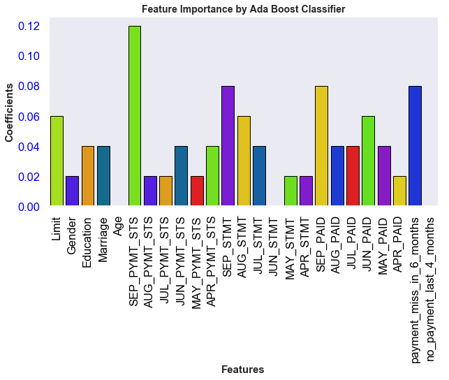

```python
from sklearn.ensemble import AdaBoostClassifier
heading = "Ada Boost Classifier"
adC     = AdaBoostClassifier()
adC.fit(train_data,train_label)
Pred       = adC.predict(test_data)
Pred_proba = adC.predict_proba(test_data)[:, 1]
score = adC.score(test_data,test_label)
roc_score  = roc_auc_score(test_label, Pred_proba)

show_features(credit_feature_df,adC.feature_importances_,score,roc_score,heading)
del(Pred)
del(Pred_proba)
del(score)
del(roc_score)
```

### Gradient Boosting Classifier

```
                    Features  Coefficients
0                      Limit      0.020556
1                     Gender      0.002798
2                  Education      0.005688
3                   Marriage      0.003757
4                        Age      0.009964
5               SEP_PYMT_STS      0.617354
6               AUG_PYMT_STS      0.080763
7               JUL_PYMT_STS      0.038616
8               JUN_PYMT_STS      0.017207
9               MAY_PYMT_STS      0.019877
10              APR_PYMT_STS      0.023098
11                  SEP_STMT      0.027965
12                  AUG_STMT      0.009276
13                  JUL_STMT      0.006850
14                  JUN_STMT      0.004812
15                  MAY_STMT      0.006805
16                  APR_STMT      0.007113
17                  SEP_PAID      0.016262
18                  AUG_PAID      0.016514
19                  JUL_PAID      0.017608
20                  JUN_PAID      0.008448
21                  MAY_PAID      0.007394
22                  APR_PAID      0.006304
23  payment_miss_in_6_months      0.017285
24  no_payment_last_4_months      0.007688

Accuracy : 82.09
AUC      : 0.78
```

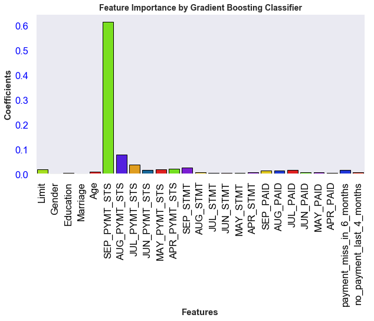

```python
from sklearn.ensemble import GradientBoostingClassifier

heading = "Gradient Boosting Classifier"

gbc = GradientBoostingClassifier()
gbc.fit(train_data,train_label)
Pred       = gbc.predict(test_data)
Pred_proba = gbc.predict_proba(test_data)[:, 1]
score      = gbc.score(test_data,test_label)
roc_score  = roc_auc_score(test_label, Pred_proba)

show_features(credit_feature_df,gbc.feature_importances_,score,roc_score,heading)
del(Pred)
del(Pred_proba)
del(score)
del(roc_score)
```

### XGBoost Classifier

```
                    Features  Coefficients
0                      Limit      0.079063
1                     Gender      0.014641
2                  Education      0.030747
3                   Marriage      0.026354
4                        Age      0.042460
5               SEP_PYMT_STS      0.073206
6               AUG_PYMT_STS      0.027818
7               JUL_PYMT_STS      0.030747
8               JUN_PYMT_STS      0.024890
9               MAY_PYMT_STS      0.017570
10              APR_PYMT_STS      0.039531
11                  SEP_STMT      0.103953
12                  AUG_STMT      0.045388
13                  JUL_STMT      0.035139
14                  JUN_STMT      0.029283
15                  MAY_STMT      0.030747
16                  APR_STMT      0.051245
17                  SEP_PAID      0.065886
18                  AUG_PAID      0.048316
19                  JUL_PAID      0.043924
20                  JUN_PAID      0.036603
21                  MAY_PAID      0.042460
22                  APR_PAID      0.023426
23  payment_miss_in_6_months      0.024890
24  no_payment_last_4_months      0.011713

Accuracy : 82.28
AUC      : 0.78
```

[figure not shown]

```python
import xgboost as xgb
from xgboost import XGBClassifier

heading    = "XGBoost Classifier"
xgb        = XGBClassifier()
xgb.fit(train_data,train_label,eval_metric='auc')
Pred       = xgb.predict(test_data)
Pred_proba = xgb.predict_proba(test_data)[:, 1]
score      = xgb.score(test_data,test_label)
roc_score  = roc_auc_score(test_label, Pred_proba)

show_features(credit_feature_df,xgb.feature_importances_,score,roc_score,heading)
del(Pred)
del(Pred_proba)
del(score)
del(roc_score)
```

```python
pd.DataFrame({'Model'    : Model,
              'Accuracy' : Accuracy,
              'AUC'      : AUC})
```

|  | AUC | Accuracy | Model |
| --- | --- | --- | --- |
| 0 | 0.649793 | 78.344444 | Logistic Regression |
| 1 | 0.616019 | 72.544444 | Decision Tree Classifier |
| 2 | 0.723001 | 80.488889 | Random Forest Classifier |
| 3 | 0.776046 | 81.911111 | Ada Boost Classifier |
| 4 | 0.781062 | 82.088889 | Gradient Boosting Classifier |
| 5 | 0.780165 | 82.277778 | XGBoost Classifier |

Model "XGBoost Classifier", "Gradient Boosting Classifier" and "Ada Boost Classifier" is the choice because of high Accuracy (number of correct predictions made by the model) and (AUC tells how much model is capable of distinguishing between classes. Higher, better). Hence attributes which contributed high Accuracy will be selected to build the model.

### Ada Boost Classifier - with Important Features

```python
adC_feature_df = credit_df_BK
adC_feature_df = adC_feature_df.drop(['Age','JUN_STMT','no_payment_last_4_months'], axis=1)
```

```python
data_adC,label_adC = adC_feature_df.iloc[:,:-1],adC_feature_df.iloc[:,-1]
train_data_adC, test_data_adC, train_label_adC, test_label_adC = train_test_split(data_adC, label_adC, test_size=0.3, random_state=123)
```

```
                    Features  Coefficients
0                      Limit          0.06
1                     Gender          0.02
2                  Education          0.04
3                   Marriage          0.04
4               SEP_PYMT_STS          0.12
5               AUG_PYMT_STS          0.02
6               JUL_PYMT_STS          0.02
7               JUN_PYMT_STS          0.04
8               MAY_PYMT_STS          0.02
9               APR_PYMT_STS          0.04
10                  SEP_STMT          0.08
11                  AUG_STMT          0.06
12                  JUL_STMT          0.04
13                  MAY_STMT          0.02
14                  APR_STMT          0.02
15                  SEP_PAID          0.08
16                  AUG_PAID          0.04
17                  JUL_PAID          0.04
18                  JUN_PAID          0.06
19                  MAY_PAID          0.04
20                  APR_PAID          0.02
21  payment_miss_in_6_months          0.08

Accuracy : 81.91
AUC      : 0.78
```

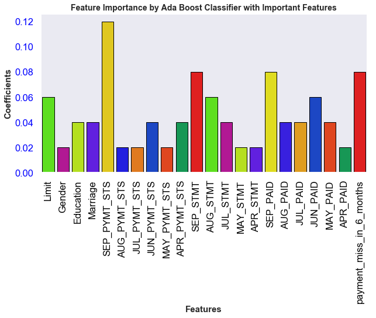

```python
heading = "Ada Boost Classifier with Important Features"
adC     = AdaBoostClassifier()
adC.fit(train_data_adC,train_label_adC)
Pred       = adC.predict(test_data_adC)
Pred_proba = adC.predict_proba(test_data_adC)[:, 1]
score      = adC.score(test_data_adC,test_label_adC)
roc_score  = roc_auc_score(test_label_adC, Pred_proba)
show_features(adC_feature_df,adC.feature_importances_,score,roc_score,heading)
del(Pred)
del(Pred_proba)
del(score)
del(roc_score)
```

### Ada Boost Classifier - Hyper Parameter Tuning

The boosting algorithm Adaboost (when using a tree) has three core parameters: - number of weak learners to train - learning rate - max nb of splits (depth of tree)

```python
from sklearn.model_selection import GridSearchCV
from sklearn.model_selection import KFold
crossvalidation=KFold(n_splits=10,shuffle=True,random_state=1)

# Create the parameter grid based on the results of random search
search_grid = {
    'n_estimators': [100,500,1000],
    'learning_rate':[0.01,0.05,0.1],
}

grid_cv_adC =GridSearchCV(estimator = adC, param_grid = search_grid, scoring='accuracy',n_jobs=1,cv=crossvalidation)
grid_cv_adC.fit(train_data_adC,train_label_adC)
print(grid_cv_adC.best_estimator_)
```

```
AdaBoostClassifier(algorithm='SAMME.R', base_estimator=None,
          learning_rate=0.05, n_estimators=500, random_state=None)
```

```python
heading = 'Ada Boost Classifier - After Parameter Tuning'

Pred_proba = grid_cv_adC.predict_proba(test_data_adC)[:, 1]
score      = grid_cv_adC.score(test_data_adC,test_label_adC)
roc_score  = roc_auc_score(test_label_adC, Pred_proba)

Get_Metrics(score,roc_score,heading)
del(score)
del(roc_score)
```

```
Ada Boost Classifier - After Parameter Tuning
Accuracy : 81.91
AUC      : 0.78
```

### XGBoost Classifier - with Important Features

```python
xgb_feature_df = credit_df_BK
```

```python
data_xgb,label_xgb = xgb_feature_df.iloc[:,:-1],xgb_feature_df.iloc[:,-1]
train_data_xgb, test_data_xgb, train_label_xgb, test_label_xgb = train_test_split(data_xgb, label_xgb, test_size=0.3, random_state=123)
```

```
                    Features  Coefficients
0                      Limit      0.079063
1                     Gender      0.014641
2                  Education      0.030747
3                   Marriage      0.026354
4                        Age      0.042460
5               SEP_PYMT_STS      0.073206
6               AUG_PYMT_STS      0.027818
7               JUL_PYMT_STS      0.030747
8               JUN_PYMT_STS      0.024890
9               MAY_PYMT_STS      0.017570
10              APR_PYMT_STS      0.039531
11                  SEP_STMT      0.103953
12                  AUG_STMT      0.045388
13                  JUL_STMT      0.035139
14                  JUN_STMT      0.029283
15                  MAY_STMT      0.030747
16                  APR_STMT      0.051245
17                  SEP_PAID      0.065886
18                  AUG_PAID      0.048316
19                  JUL_PAID      0.043924
20                  JUN_PAID      0.036603
21                  MAY_PAID      0.042460
22                  APR_PAID      0.023426
23  payment_miss_in_6_months      0.024890
24  no_payment_last_4_months      0.011713

Accuracy : 82.28
AUC      : 0.78
```

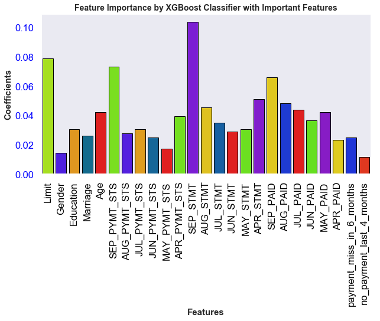

```python
heading = "XGBoost Classifier with Important Features"

xgb = XGBClassifier()
xgb.fit(train_data_xgb,train_label_xgb,eval_metric='auc')
Pred_proba = xgb.predict_proba(test_data_xgb)[:, 1]
score      = xgb.score(test_data_xgb,test_label_xgb)
roc_score  = roc_auc_score(test_label_xgb, Pred_proba)

show_features(credit_feature_df,xgb.feature_importances_,score,roc_score,heading)
del(Pred_proba)
del(score)
del(roc_score)
```

### XGBoosting Classifier - Hyper Parameter Tuning

```python
search_grid = {
              'n_estimators': [100,500],
              'max_depth':[4],
              'min_child_weight':[1],
              'subsample': [0.8],
              'learning_rate':[0.01]}

xgb =GridSearchCV(estimator = xgb, param_grid = search_grid,n_jobs=1,cv=crossvalidation)

xgb.fit(train_data_xgb,train_label_xgb)
print(xgb.best_estimator_)
```

```
XGBClassifier(base_score=0.5, booster='gbtree', colsample_bylevel=1,
       colsample_bytree=1, gamma=0, learning_rate=0.01, max_delta_step=0,
       max_depth=4, min_child_weight=1, missing=None, n_estimators=500,
       n_jobs=1, nthread=None, objective='binary:logistic', random_state=0,
       reg_alpha=0, reg_lambda=1, scale_pos_weight=1, seed=None,
       silent=True, subsample=0.8)
```

```python
heading = 'XG Boosting Classifier - After Parameter Tuning'

Pred_proba = xgb.predict_proba(test_data_xgb)[:, 1]
score      = xgb.score(test_data_xgb,test_label_xgb)
roc_score  = roc_auc_score(test_label_xgb, Pred_proba)

Get_Metrics(score,roc_score,heading)
del(Pred_proba)
del(score)
del(roc_score)
```

```
XG Boosting Classifier - After Parameter Tuning
Accuracy : 82.29
AUC      : 0.78
```

### Gradient Boosting Classifier - with Important Features

```python
GB_feature_df = credit_df_BK
GB_feature_df = GB_feature_df.drop(['Gender','Marriage'], axis=1)
```

```python
data_GB,label_GB = GB_feature_df.iloc[:,:-1],GB_feature_df.iloc[:,-1]
train_data_GB, test_data_GB, train_label_GB, test_label_GB = train_test_split(data_GB, label_GB, test_size=0.3, random_state=123)
```

```
                    Features  Coefficients
0                      Limit      0.021685
1                  Education      0.005467
2                        Age      0.010054
3               SEP_PYMT_STS      0.616839
4               AUG_PYMT_STS      0.079113
5               JUL_PYMT_STS      0.038178
6               JUN_PYMT_STS      0.017818
7               MAY_PYMT_STS      0.020231
8               APR_PYMT_STS      0.023660
9                   SEP_STMT      0.028128
10                  AUG_STMT      0.009801
11                  JUL_STMT      0.005288
12                  JUN_STMT      0.006537
13                  MAY_STMT      0.005792
14                  APR_STMT      0.008477
15                  SEP_PAID      0.015760
16                  AUG_PAID      0.017513
17                  JUL_PAID      0.018798
18                  JUN_PAID      0.008758
19                  MAY_PAID      0.009084
20                  APR_PAID      0.007536
21  payment_miss_in_6_months      0.016269
22  no_payment_last_4_months      0.009211

Accuracy : 82.17
AUC      : 0.78
```

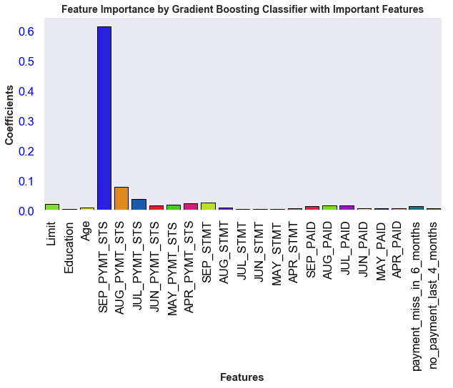

```python
heading = "Gradient Boosting Classifier with Important Features"

gbc = GradientBoostingClassifier()
gbc.fit(train_data_GB,train_label_GB)
Pred_proba = gbc.predict_proba(test_data_GB)[:, 1]
score      = gbc.score(test_data_GB,test_label_GB)
roc_score  = roc_auc_score(test_label_GB, Pred_proba)

show_features(GB_feature_df,gbc.feature_importances_,score,roc_score,heading)
del(Pred_proba)
del(score)
del(roc_score)
```

### Gradient Boosting Classifier - Hyper Parameter Tuning

```python
from sklearn.model_selection import GridSearchCV

search_grid = {
              'n_estimators': [500],
              'max_depth':[4],
              'min_samples_split': [10],
              'min_samples_leaf':[8],
              'learning_rate':[0.1,0.05,0.01]}

clf = GridSearchCV(estimator = GradientBoostingClassifier(random_state=1),
                   param_grid = search_grid, scoring='accuracy').fit(train_data_GB,train_label_GB)


print(clf.best_estimator_)
```

```
GradientBoostingClassifier(criterion='friedman_mse', init=None,
              learning_rate=0.01, loss='deviance', max_depth=4,
              max_features=None, max_leaf_nodes=None,
              min_impurity_decrease=0.0, min_impurity_split=None,
              min_samples_leaf=8, min_samples_split=10,
              min_weight_fraction_leaf=0.0, n_estimators=500,
              n_iter_no_change=None, presort='auto', random_state=1,
              subsample=1.0, tol=0.0001, validation_fraction=0.1,
              verbose=0, warm_start=False)
```

```python
heading = 'Gradient Boosting - After Parameter Tuning'
Pred_proba = clf.predict_proba(test_data_GB)[:, 1]
score      = clf.score(test_data_GB,test_label_GB)
roc_score  = roc_auc_score(test_label_GB, Pred_proba)
Get_Metrics(score,roc_score,heading)
del(Pred_proba)
del(score)
del(roc_score)
```

```
Gradient Boosting - After Parameter Tuning
Accuracy : 82.24
AUC      : 0.78
```

```python
#score      = clf.score(test_data_GB,test_label_GB)
#score
#roc_score  = roc_auc_score(test_label_GB, Pred_proba)
```

```python
pd.DataFrame({'Model'    : Model,
              'Accuracy' : Accuracy,
              'AUC'      : AUC})
```

|  | AUC | Accuracy | Model |
| --- | --- | --- | --- |
| 0 | 0.649793 | 78.344444 | Logistic Regression |
| 1 | 0.616019 | 72.544444 | Decision Tree Classifier |
| 2 | 0.723001 | 80.488889 | Random Forest Classifier |
| 3 | 0.776046 | 81.911111 | Ada Boost Classifier |
| 4 | 0.781062 | 82.088889 | Gradient Boosting Classifier |
| 5 | 0.780165 | 82.277778 | XGBoost Classifier |
| 6 | 0.776046 | 81.911111 | Ada Boost Classifier with Important Features |
| 7 | 0.780165 | 82.277778 | XGBoost Classifier with Important Features |
| 8 | 0.779515 | 82.166667 | Gradient Boosting Classifier with Important Fe... |

```python
pd.DataFrame({'Model'    : Model_,
              'Accuracy' : Accuracy_,
              'AUC'      : AUC_})
```

|  | AUC | Accuracy | Model |
| --- | --- | --- | --- |
| 0 | 0.775472 | 81.911111 | Ada Boost Classifier - After Parameter Tuning |
| 1 | 0.781455 | 82.288889 | XG Boosting Classifier - After Parameter Tuning |
| 2 | 0.780169 | 82.244444 | Gradient Boosting - After Parameter Tuning |

Model "XG Boosting Classifier", an advanced implementation of gradient boosting algorithm and model "Gradient Boosting Classifier" are high accuracy and AUC when compared to the other models. Hence attributes which contributed high accuracy & AUC will be selected to build the model.

### Gradient Boosting Model with joblib to use it to make new predictions on the unseen data

```python
from sklearn.externals import joblib
filename = 'final_model_payment_defaulter.sav'
joblib.dump(clf, filename)
```

```
['final_model_payment_defaulter.sav']
```